# Analisis problemas visuales en la Región Metropolitana

Manuel Astroza

2025-06-29

# Introducción

Para este trabajo se va a reutilizar la variable problemas de visión (variable h7a de la CASEN) del trabajo 2 con el fin de correlacionar con las variables edad e ingreso y asignar correlaciones específicas a grupos fácilmente localizables en el espacio mediante la aplicación del algoritmo de k-means que permite identificar patrones y estructuras ocultas en datos no etiquetados, agrupando observaciones similares.

Este estudio permite entender cómo se distribuyen las variables en diferentes subpoblaciones o clusters.

La hipótesis del trabajo es que es la población mayor de menores ingresos la que presentaría mayores índices de problemas de visión.

# Justificación de la elección

La Región Metropolitana es la zona con mayor concentración poblacional y diversidad socioeconómica, lo que implica heterogeneidad en la prevalencia y acceso a servicios de salud visual.

Los problemas de vista son una condición de salud que afecta la calidad de vida y la productividad.

Según la Organización Mundial de la Salud, la discapacidad visual representa una enorme carga económica mundial, con un costo anual en términos de productividad estimado en 411 mil millones de dólares, lo que sugiere que las personas con problemas visuales pueden enfrentar desventajas económicas importantes (OMS, 2023).

## Variables de estudio

Respecto al trabajo anterior, se redefinen las variables de estudio.

Se considera como población sana aquellos que se encuentran sanos o presentan leves problemas (respuestas 1 y 2 de la CASEN).

Luego se considera como población mayor la edad de 40 año pues en esta la visión de cerca comienza a fallar y las personas comienzan a necesitar lentes de lectura, esto es conocido como presbicia, la cuál ocurre cuando la capacidad de acomodación del cristalino (nuestro lente interno natural) comienza a disminuir progresivamente (Centro de la visión, 2023).

Tasa de visión:
$$\text{Tasa de problemas
de vision} = 100 \cdot \frac{\sum{x = 0}}{n}$$

X: Valores de “h7a”. n: Total de población.

Tasa de mayores de 40 años:
$$\text{Tasa
de mayores} = 100 \cdot \frac{\sum{x \geq 40}}{n}$$

X: Valores de “edad”. n: Total de población.

Ingreso promedio:
$$\text{Ingreso
promedio} = \frac{\sum{x}}{n}$$

X: Valores de “ypc”. n: Total de población.

# Marco teórico

El algoritmo k-means es un método de agrupamiento no supervisado que divide un conjunto de datos en “k” grupos (clusters) que presentan puntos similares entre sí. El objetivo del algoritmo es minimizar la suma de las distancias entre los puntos de datos y el centroide de su cluster, lo que permite obtener grupos compactos y bien definidos. Su funcionamiento básico consiste en: - Elegir k centroides iniciales (puntos centrales de cada grupo), generalmente de forma aleatoria. - Asignar cada punto de datos al cluster cuyo centroide esté más cercano, usando una medida de distancia (normalmente euclidiana). - Recalcular los centroides como la media de los puntos asignados a cada cluster. - Repetir los pasos 2 y 3 hasta que los centroides ya no cambien o se alcance un número máximo de iteraciones.

El índice de Shannon (también conocido como entropía de Shannon) es una medida de diversidad que se puede aplicar al análisis de agrupamientos (clustering) como el de k-means para evaluar la diversidad o heterogeneidad dentro de un grupo o zona.

$$H = -\sum_{i=1}^{k} p_i \cdot
\log_2(p_i)$$
Donde: H: Índice de Shannon (entropía) k: Número total de clústers pi: Proporción de elementos que pertenecen al clúster

# Area de estudio

Según proyecciones del Instituto Nacional de Estadísticas (INE) para 2025 la región tendrá 8.47 millones de habitantes aproximadamente, representando el 41.9% de la población total del país. La distribución por sexo es equilibrada, con un 50.5% mujeres y 49.5% hombres. En términos de edad, el 16.8% serán menores de 14 años, el 4.8% adolescentes (14-17 años), y un 18% adultos mayores (60 años o más), evidenciando una población con un importante segmento envejecido.

La Región Metropolitana es el principal motor económico del país, concentrando gran parte de la actividad productiva nacional. Destacan sectores como comercio, construcción, servicios profesionales, financieros e industria manufacturera. La región atrae inversiones públicas y privadas que impulsan el desarrollo urbano y económico generando oportunidades laborales diversas.

Los niveles de pobreza son relativamente bajos en comparación con el resto del país, pero con heterogeneidades internas. La pobreza por ingresos en algunas comunas es baja más la pobreza multidimensional (que considera acceso a educación, salud, vivienda y otros servicios) es más dispar en ciertos sectores.

Considerando lo anterior se puede dividir geográficamente la región de la siguiente manera.

- Zona Centro: Suele concentrar actividades comerciales y administrativas, con ingresos variables, pero en general presenta un nivel medio de ingresos.
- Zona Norte: Tiene una mezcla de sectores industriales y residenciales, con ingresos que pueden ser medios a bajos.
- Zona Sur: Predominan sectores con ingresos medios a bajos, con mayor presencia de población con educación básica incompleta.
- Zona Este: Es la zona con mayores ingresos promedio, alta escolaridad y mejor acceso a servicios, caracterizada por un nivel socioeconómico alto.
- Zona Oeste: Presenta ingresos medios a bajos, con una mayor proporción de población con menor nivel educacional y mayor vulnerabilidad social.

# Desarrollo

Para realizar estre trabajo se consideran las siguientes librerías que permiten conectar con Postgres para una mejor consulta de datos, microsimular y generar mapas.

```r
# 1. Librerías
library(RPostgres)  # Conectar a Postgres
library(DBI)         # Manipular bases de datos
library(ggplot2)     # Visualización
library(sf)          # Manejo de geometría
library(factoextra)  # K-means
library(GGally)      # Gráficos de correlación
library(rakeR)       # Microsimulación
library(vegan)       # Cálculo de diversidad
library(dplyr)       # Manipulación de datos
library(tidyr)       # Transformaciones de datos
library(tibble)      # Para tibble
library(RColorBrewer) # Paletas de colores
```

Se realiza un preprocesamiento identico al del trabajo anterior. Este mismo se omite, sin embargo vale comentar que se redefine h7a para tomar como “1” los valores 1 y 2 y “0” los valores 3 y 4.

Sin embargo, las métricas se calculan de forma diferente, pues se agrega la obtención de un ingreso promedio microsimulado, por ende esta parte si se muestra.

```r
# 5. Cálculo de métricas
zonas_stats <- aggregate(
  cbind(h7a, edad, ypc) ~ zone, # Variables microsimuladas
  data = sim_df,
  FUN = function(x) x
)
rm(sim_df) # Descartar variable

# Calcular indices mediante funciones y elimnar valores vacíos
zonas_stats <- within(zonas_stats, {
  tasa_vision = round(100 * sapply(h7a, function(x) sum(x == 0, na.rm = TRUE) / length(x)), 2)
  tasa_mayores = round(100 * sapply(edad, function(x) sum(x >= 40, na.rm = TRUE) / length(x)), 2)
  ingreso = round(sapply(ypc, function(x) mean(x, na.rm = TRUE)), 2)
})
# Agregar a un data frame
zonas_stats_df <- data.frame(
  geocodigo = zonas_stats$zone,
  tasa_vision = zonas_stats$tasa_vision,
  tasa_mayores = zonas_stats$tasa_mayores,
  ingreso = zonas_stats$ingreso
)
# Escalar variables de estudio
vars_scaled <- scale(zonas_stats_df[, c("tasa_vision", "tasa_mayores", "ingreso")])
```

Se aplica el método del codo para determinar el número de clústers a trabajar. Este consiste en ver dónde el gráfico posee la mayor variación de pendiente para seleccionar dicho punto. Además se escalan las variables para que no predomine una sobre otra al agrupar.

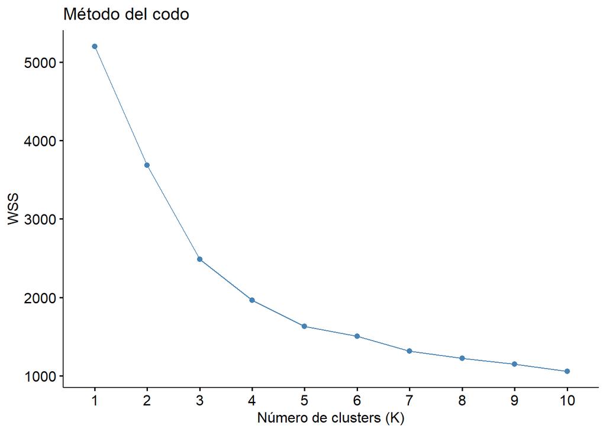

```r
# 6. Kmeans
# 6.1 Método del codo: Visualiza la suma de cuadrados dentro del cluster (WSS) para varios K
fviz_nbclust(vars_scaled, kmeans, method = "wss") + # Datos, algoritmo, método de selección
  labs(title = "Método del codo", x = "Número de clusters (K)", y = "WSS")
```

```r
# 6.2 Calcular kmeans
set.seed(123)  # Para reproducibilidad
km = kmeans(vars_scaled, centers = 3, nstart = 25) # Introducir k determinado (3)
zonas_stats_df$cluster = as.factor(km$cluster) # Agregar número de cluster a la tabla
rm(vars_scaled)
```

Creación de un mapa de correlaciones mediante consulta PGAdmin para vincular con la geometría según la variable “gecódigo”.

```r
# 7. Conexión con Postgres
con <- dbConnect(
  Postgres(),
  dbname = "censo_rm_2017",
  host = "localhost",
  port = 5432,
  user = "postgres",
  password = "postgres"
)

dbWriteTable(
  conn = con,
  name = Id(schema = "dpa", table = "tmp_vision_vejez_rm"),
  value = zonas_stats_df,
  overwrite = TRUE,
  row.names = FALSE
)

# 7.1 Crear tabla optimizando con indice y descartando tabla anterior
dbExecute(con, "CREATE INDEX ON dpa.tmp_vision_vejez_rm(geocodigo)")
```

```
## [1] 0
```

```r
dbExecute(con, "ANALYZE dpa.tmp_vision_vejez_rm")
```

```
## [1] 0
```

```r
dbExecute(con, "DROP TABLE IF EXISTS dpa.zonas_vision_vejez")
```

```
## [1] 0
```

```r
dbExecute(con, "
  CREATE TABLE dpa.zonas_vision_vejez AS
  SELECT
    z.*,
    t.tasa_vision AS vision,
    t.tasa_mayores AS vejez,
    t.ingreso AS ingreso,
    t.cluster
  FROM dpa.zonas_censales_rm AS z
  LEFT JOIN dpa.tmp_vision_vejez_rm AS t
    ON z.geocodigo::text = t.geocodigo
  WHERE urbano = 1
    AND (nom_provin = 'SANTIAGO' OR nom_comuna = 'SAN BERNARDO' OR nom_comuna = 'PUENTE ALTO')
")
```

```
## [1] 1644
```

```r
# Seleccionar variables del mapa
sf_mapa <- st_read(con, query = "
  SELECT * FROM dpa.zonas_vision_vejez
")

# Seleccionar geometría de comunas
sql_comunas <- "
SELECT cut, nom_comuna, geom
FROM dpa.comunas_rm_shp
WHERE nom_provin = 'SANTIAGO';
"
sf_comunas <- st_read(con, query = sql_comunas)
```

Se genera un indice de shannon que permite ver la variabilidad en el mapa.

```r
# 8. Generar indices de Shannon
# 8.1 Crear la tabla con el conteo de clusters por comuna
tabla_shannon <- sf_mapa |>
  st_drop_geometry() |>
  count(nom_comuna, cluster) |>
  filter(!is.na(nom_comuna)) |>
  tidyr::pivot_wider(names_from = cluster, values_from = n, values_fill = 0) |>
  column_to_rownames("nom_comuna")

# 8.2 Calcular el índice de Shannon para cada comuna
shannon <- diversity(tabla_shannon, index = "shannon")

# Crear un data frame con el índice de Shannon por comuna y unir por comuna
df_shannon <- data.frame(
  nom_comuna = names(shannon),
  shannon_index = shannon
)
sf_comunas_shannon <- merge(sf_comunas, df_shannon, by = "nom_comuna")
```

# Resultados

A continuación se presentan los gráficos de correlaciones, seguido del mapa de variables agrupadas y el mapa de variabilidad para las variables estudiadas.

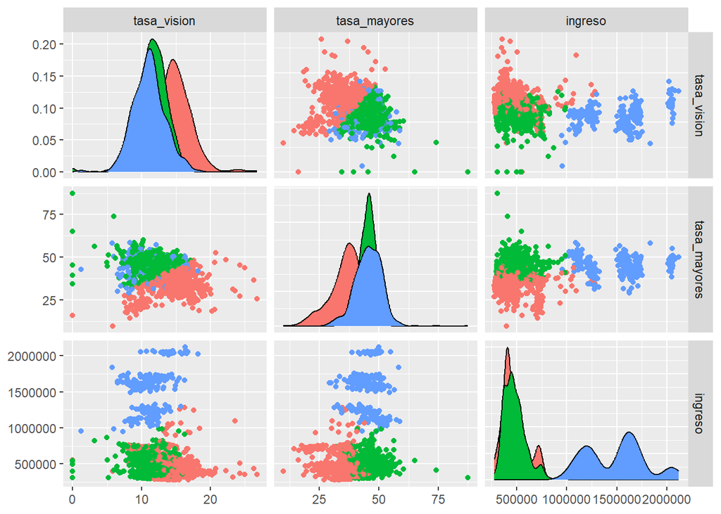

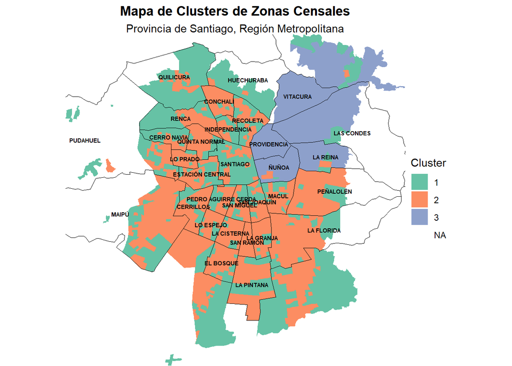

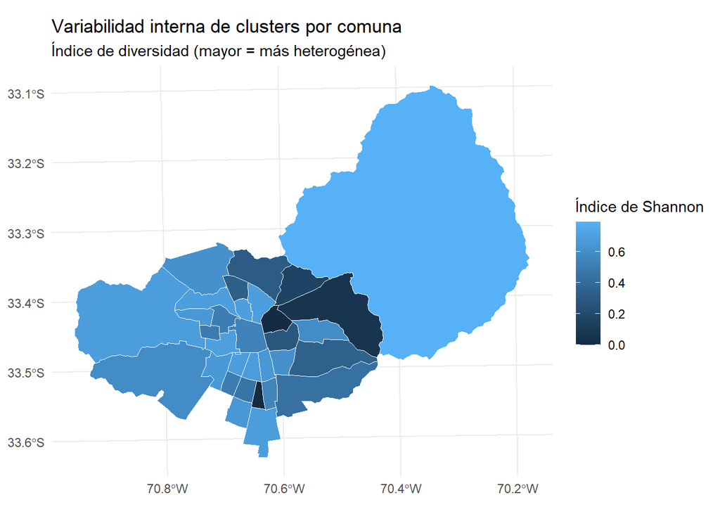

# Análisis

## Análisis de clústers y correlaciones

Analizar los gráficos de dispersión es posible caracterizar de la siguiente forma, considerando los términos “bajos-altos” según los rangos porcentuales descritos:

| Cluster | Tasa de Visión | Proporción >40 años | Ingreso |
| --- | --- | --- | --- |
| 1 (Verde) | Baja | Alta | Bajo |
| 2 (Rojo) | Alta | Baja | Bajo |
| 3 (Azul) | Baja | Media | Alto |

El cluster 1 son zonas con mayor proporción de adultos mayores, pero con una menor prevalencia de problemas visuales. Posee ingresos bajos, similar al grupo 2.

El cluster 2 destaca por poseer mayores problemas visuales, siendo la única que alcanza picos sobre 20% pero la población de mayores es la menor de los grupos. Presenta los ingresos más bajos, más no dista del grupo 1.

## Análisis del mapa agrupado

La zona norte posee una importante división respecto al trabajo 2. Predomina el grupo 1 al oeste, con incrustaciones del grupo 2 a medida que se “baja al sur”. En estos sectores hay población más vieja, pero con bajos índices de problemas de salud, lo que indica una mejor calidad de vida para estos.

En el noreste predomina notablemente el grupo 3, siendo el área más uniforme del mapa. Es importante recalcar que este grupo posee la mayor variación de ingresos a pesar de tener mayor promedio. Se puede decir que acá el factor ingreso podría ser menos relevante y otras variables como conectividad o educación influyen en tener menores problemas tanto para jóvenes como adultos.

Respecto a la zona centro predomina el cluster 1 solo en la comuna de Santiago, esto indicaría que en la comuna de Santiago que pese a tener mayor proporción de adultos mayores e ingresos bajos su buena conectividad ofrece una mejor respuesta a la prevención de problemas.

Comunas aledañas (sin contar noreste) y casi la totalidad del sur predomina el cluster 2. Este grupo se caracteriza por alcanzar los ingresos más bajos, mayores tasas de problemas de visión y población más joven.

Como se comentó en la justificación de la variable, los problemas de visión suelen aparecer a los 40 años pero también se pueden desarrollar en edades jóvenes, siendo el caso de este grupo. Además de el factor acceso a la salud (ya sea por conectividad e ingreso) la educación también es fundamental para prevenir, por lo que se justifica la correlación presente.

## Análisis del mapa de variabilidad

El gran polígono grande no corresponde al área de estudio y no se considera.

Las Condes, Ñuñoa y Providencia son las comunas con menos variabilidad, en este caso del cluster 3, presentando mayores ingresos y mejor calidad de vida respecto a la salud en visión.

El resto de la región presenta una alta variabilidad, especialmente en comunas aledañas a Santiago, variando entre los cluster 1 y 2, que son similares en ingresos pero discrepan en edad y salud visual. Destaca San Ramón con una alta homogeneidad, en este caso del cluster 2, siendo la comuna que presenta mayores problemas junto a menor proporción de mayores a 40 años.

# Conclusión

Este trabajo permitió correlacionar 3 variables de la CASEN, estudiarlas a nivel zona censal y generar 3 grupos (determinados mediante el método del codo) mediantes el procedimiento de k-means

El Cluster 3 muestra mejores condiciones generales de vida con menores problemas visuales, edad variable y alta heterogeneidad en ingresos con un promedio alto, sugiriendo que factores como educación, infraestructura y acceso a salud también juegan un rol protector.

Por otro lado, el Cluster 2 (predominante en el sur y áreas periféricas) representa zonas con un desafío social único: es población más joven de ingresos más bajos la que presenta altos niveles de problemas visuales, rechazando la hipótesis.

Estas características reflejan una mayor vulnerabilidad estructural, posiblemente influenciada por el menor acceso a servicios de salud, educación y prevención. También señala la urgencia de atender estos problemas en población joven, destacando la comuna de San Ramón

El Cluster 1, con características intermedias, destaca por su alta proporción de adultos mayores pero menor prevalencia de problemas visuales, lo que podría reflejar una cierta estabilidad pese a sus bajos ingresos.

Territorialmente, se identifican patrones espaciales coherentes con la desigualdad estructural ya conocida en Santiago: un noreste consolidado y de alto bienestar, un centro mixto y con signos de envejecimiento positivo y un sur vulnerable donde confluyen juventud, pobreza y mayores riesgos sanitarios.

Se deberían aplicar políticas especialmente a la zona centro sur enfocadas en personas jóvenes. Para futuras investigaciones es posible llevar estos mapas a formato JSON para estudiarlos en plataformas GIS, así como considerar otras variables, como el sexo o nivel educacional, pues este último pareciera ser relevante.

# Bibliografía

Telencuestas. (2023, agosto 29). Población de la Región Metropolitana de Santiago en 2025. Telencuestas. https://telencuestas.com/censos-de-poblacion/chile/2025/metropolitana-de-santiago

Ministerio de Desarrollo Social y Familia. (2020). Índice de prioridad social 2020 [Informe]. Gobierno de Chile. https://www.desarrollosocialyfamilia.gob.cl/storage/docs/boletin_interno/INDICE_DE_PRIORIDAD_SOCIAL_2020(1).pdf

World Health Organization: WHO. (2023, 10 agosto). Ceguera y discapacidad visual. https://www.who.int/es/news-room/fact-sheets/detail/blindness-and-visual-impairment

Centro de la Visión. (2024, marzo). Chequeos de la visión según la edad. Centro de la Visión. https://centrodelavision.cl/sn/chequeos-de-la-vision-segun-la-edad/